# 탐색적자료분석

### 2019년 도로(Road) 자료 : road_2019.csv

- 2019년 우리나라(Korea) 고속도로에 대한 자료
- 고속도로 콘존별 좌표와 날짜, 도로포장형태, 표층재, 결빙취약지역, 기상상태 등을 파악할 수 있는 자료

[output not shown]

- 목적 : 탐색적자료분석 근거를 기반으로 회귀모형을 모형화하고 추정된 회기계수 바탕으로 변수 중요도, 위험지수 창출

## 패키지 불러오기

```r
library(tidyverse)
library(ggplot2)
library(GGally)
library(grid)
library(gridExtra)
library(knitr)
library(kableExtra)
```

```r
setwd("C:/Users/Administrator/Desktop/data")

df <- read_csv("road_2019.csv",locale=locale('ko',encoding='euc-kr'))
```

## 데이터 구조 파악

```r
nrow(df) # 데이터 행 개수
```

151000

```r
df %>% head(5) # 데이터 상위 5행
df %>% tail(5) # 데이터 하위 5행
```

| date | czId | routeNo | routeName | direction | czstart | czend | s_Xvalue | s_Yvalue | s_elevation | ... | Wind_direction | Avg_windspeed | Avg_dewpoint_temp | Avg_relative_humidity | Sunlight_time | Deepest_snow | Avg_ground_temp | weather | Fog_time | Risk_dummy |
| --- | --- | --- | --- | --- | --- | --- | --- | --- | --- | --- | --- | --- | --- | --- | --- | --- | --- | --- | --- | --- |
| 20190101 | 0010CZE010 | 10 | 경부선 | E | 0.2 | 2.0 | 35.24792 | 129.0947 | 27.86905 | ... | 340 | 4.2 | -10.7 | 41.9 | 9.2 | 0 | 2.3 | 맑음 | 0 | 0 |
| 20190101 | 0010CZE011 | 10 | 경부선 | E | 2.0 | 4.0 | 35.26198 | 129.1041 | 72.28181 | ... | 340 | 4.2 | -10.7 | 41.9 | 9.2 | 0 | 2.3 | 맑음 | 0 | 0 |
| 20190101 | 0010CZE020 | 10 | 경부선 | E | 4.0 | 5.0 | 35.27896 | 129.1066 | 41.61511 | ... | 340 | 4.2 | -10.7 | 41.9 | 9.2 | 0 | 2.3 | 맑음 | 0 | 0 |
| 20190101 | 0010CZE030 | 10 | 경부선 | E | 5.0 | 5.5 | 35.28665 | 129.1011 | 60.78810 | ... | 340 | 4.2 | -10.7 | 41.9 | 9.2 | 0 | 2.3 | 맑음 | 0 | 0 |
| 20190101 | 0010CZE035 | 10 | 경부선 | E | 5.5 | 12.8 | 35.28926 | 129.0966 | 75.65348 | ... | 340 | 4.2 | -10.7 | 41.9 | 9.2 | 0 | 2.3 | 맑음 | 0 | 0 |

| date | czId | routeNo | routeName | direction | czstart | czend | s_Xvalue | s_Yvalue | s_elevation | ... | Wind_direction | Avg_windspeed | Avg_dewpoint_temp | Avg_relative_humidity | Sunlight_time | Deepest_snow | Avg_ground_temp | weather | Fog_time | Risk_dummy |
| --- | --- | --- | --- | --- | --- | --- | --- | --- | --- | --- | --- | --- | --- | --- | --- | --- | --- | --- | --- | --- |
| 20191231 | 5510CZE030 | 5510 | 중앙선지선 | E | 15.6 | 17.4 | 35.32495 | 129.0249 | 4.619035 | ... | 290 | 3 | -16.8 | 28.3 | 9.3 | 0 | 1.4 | 흐림 | 0 | 0 |
| 20191231 | 5510CZS005 | 5510 | 중앙선지선 | S | 9.1 | 0.0 | 35.28091 | 128.9843 | 19.314329 | ... | 290 | 3 | -16.8 | 28.3 | 9.3 | 0 | 1.4 | 흐림 | 0 | 0 |
| 20191231 | 5510CZS010 | 5510 | 중앙선지선 | S | 13.3 | 9.1 | 35.30812 | 129.0121 | 0.240193 | ... | 290 | 3 | -16.8 | 28.3 | 9.3 | 0 | 1.4 | 흐림 | 0 | 0 |
| 20191231 | 5510CZS020 | 5510 | 중앙선지선 | S | 15.6 | 13.3 | 35.32495 | 129.0249 | 4.619035 | ... | 290 | 3 | -16.8 | 28.3 | 9.3 | 0 | 1.4 | 흐림 | 0 | 0 |
| 20191231 | 5510CZS030 | 5510 | 중앙선지선 | S | 17.4 | 15.6 | 35.33491 | 129.0402 | 30.971682 | ... | 290 | 3 | -16.8 | 28.3 | 9.3 | 0 | 1.4 | 흐림 | 0 | 0 |

```r
glimpse(df) # str(df), 데이터 구조
```

```
Observations: 151,000
Variables: 46
$ date                        <dbl> 20190101, 20190101, 20190101, 20190101,...
$ czId                        <chr> "0010CZE010", "0010CZE011", "0010CZE020...
$ routeNo                     <dbl> 10, 10, 10, 10, 10, 10, 10, 10, 10, 10,...
$ routeName                   <chr> "경부선", "경부선", "경부선", "경부선", "경부선", "경부선...
$ direction                   <chr> "E", "E", "E", "E", "E", "E", "E", "E",...
$ czstart                     <dbl> 0.2, 2.0, 4.0, 5.0, 5.5, 12.8, 17.9, 31...
$ czend                       <dbl> 2.0, 4.0, 5.0, 5.5, 12.8, 17.9, 31.0, 3...
$ s_Xvalue                    <dbl> 35.24792, 35.26198, 35.27896, 35.28665,...
$ s_Yvalue                    <dbl> 129.0947, 129.1041, 129.1066, 129.1011,...
$ s_elevation                 <dbl> 27.86905, 72.28181, 41.61511, 60.78810,...
$ e_Xvalue                    <dbl> 35.26198, 35.27896, 35.28665, 35.28926,...
$ e_Yvalue                    <dbl> 129.1041, 129.1066, 129.1011, 129.0966,...
$ e_elevation                 <dbl> 72.28181, 41.61511, 60.78810, 75.65348,...
```

[output cut: 33 more lines]

## 데이터 전처리

- 서로 다른 데이터셋을 합치고 결측값 처리할때 엑셀을 활용하였음 (ER Diamgram 참고)
- 범주형변수들은 회귀분석을 위해 가변수 처리하였음

```r
# 범주형변수 factor 처리
df$VMS_keyword <- as.factor(df$VMS_keyword)
df$pave <- as.factor(df$pave)
df$surface <- as.factor(df$surface)
df$bridge_surface <- as.factor(df$bridge_surface)
df$classification <- as.factor(df$classification)
df$bridge_lane <- as.factor(df$bridge_lane)
df$bridge_pave <- as.factor(df$bridge_pave)
df$bridge <- as.factor(df$bridge)
df$tunnel <- as.factor(df$tunnel)
df$grooving <- as.factor(df$grooving)
df$ice_leak <- as.factor(df$ice_leak)
df$weather <- as.factor(df$weather)
```

```r
# 결측값 확인
sum(is.na(df))
```

0

- 데이터 내의 결측값 수는 0

```r
# 기존변수를 이용해서 새 변수 만들기
df <- df %>%
  mutate(cz_length = abs(df$czend - df$czstart)) # 콘존 길이
```

## 수치형 변수 탐색

```r
df_numeric <- df[,c(25, 29:43, 45, 46)] # 데이터에서 수치형 변수만 추출
df_numeric %>% head(5)
```

| traffic | Avg_temp | Mini_temp | Mini_temp_time | Max_temp | Max_temp_time | precipitation_duration_time | day_precipitation | Max_windspeed | Wind_direction | Avg_windspeed | Avg_dewpoint_temp | Avg_relative_humidity | Sunlight_time | Deepest_snow | Avg_ground_temp | Fog_time | Risk_dummy |
| --- | --- | --- | --- | --- | --- | --- | --- | --- | --- | --- | --- | --- | --- | --- | --- | --- | --- |
| 35229 | 1 | -1.9 | 621 | 5.5 | 1526 | 0 | 0 | 7.1 | 340 | 4.2 | -10.7 | 41.9 | 9.2 | 0 | 2.3 | 0 | 0 |
| 34561 | 1 | -1.9 | 621 | 5.5 | 1526 | 0 | 0 | 7.1 | 340 | 4.2 | -10.7 | 41.9 | 9.2 | 0 | 2.3 | 0 | 0 |
| 34406 | 1 | -1.9 | 621 | 5.5 | 1526 | 0 | 0 | 7.1 | 340 | 4.2 | -10.7 | 41.9 | 9.2 | 0 | 2.3 | 0 | 0 |
| 29546 | 1 | -1.9 | 621 | 5.5 | 1526 | 0 | 0 | 7.1 | 340 | 4.2 | -10.7 | 41.9 | 9.2 | 0 | 2.3 | 0 | 0 |
| 30945 | 1 | -1.9 | 621 | 5.5 | 1526 | 0 | 0 | 7.1 | 340 | 4.2 | -10.7 | 41.9 | 9.2 | 0 | 2.3 | 0 | 0 |

```r
options(digit=2)
cor(df_numeric)
```

|  | traffic | Avg_temp | Mini_temp | Mini_temp_time | Max_temp | Max_temp_time | precipitation_duration_time | day_precipitation | Max_windspeed | Wind_direction | Avg_windspeed | Avg_dewpoint_temp | Avg_relative_humidity | Sunlight_time | Deepest_snow | Avg_ground_temp | Fog_time | Risk_dummy |
| --- | --- | --- | --- | --- | --- | --- | --- | --- | --- | --- | --- | --- | --- | --- | --- | --- | --- | --- |
| traffic | 1.000000000 | -0.019332013 | 0.01624643 | -0.033071805 | -0.05136624 | 0.041475043 | 0.09518939 | -0.009806204 | -0.001174893 | 0.0382836413 | 0.055909337 | -0.068274394 | -0.10485551 | 0.04014939 | 0.0295583816 | -0.03478079 | 0.031266743 | -0.016792093 |
| Avg_temp | -0.019332013 | 1.000000000 | 0.92396644 | -0.002482543 | 0.93306964 | 0.022701648 | 0.06469934 | 0.142662598 | 0.035936484 | -0.1250991342 | -0.025349245 | 0.823042620 | 0.27152166 | -0.08652040 | -0.0658942724 | 0.93945006 | 0.045471697 | -0.018013143 |
| Mini_temp | 0.016246431 | 0.923966445 | 1.00000000 | 0.093787706 | 0.76366928 | -0.049354598 | 0.16069871 | 0.189001686 | 0.120845477 | -0.0791890794 | 0.104855575 | 0.797428984 | 0.29886788 | -0.18009082 | -0.0226014010 | 0.88200099 | 0.075700298 | 0.070599837 |
| Mini_temp_time | -0.033071805 | -0.002482543 | 0.09378771 | 1.000000000 | -0.09053000 | -0.425409434 | 0.13544217 | 0.040371322 | 0.256188274 | 0.1615787233 | 0.280797354 | 0.031249685 | 0.05249556 | -0.11120488 | 0.0184132167 | 0.05799530 | 0.021602802 | 0.168805129 |
| Max_temp | -0.051366243 | 0.933069640 | 0.76366928 | -0.090530002 | 1.00000000 | 0.080147390 | -0.05328852 | 0.064445547 | -0.075108197 | -0.1530127975 | -0.166803871 | 0.741544405 | 0.22223481 | 0.06105985 | -0.0960296996 | 0.88159990 | 0.019122725 | -0.122653082 |
| Max_temp_time | 0.041475043 | 0.022701648 | -0.04935460 | -0.425409434 | 0.08014739 | 1.000000000 | -0.11883857 | -0.061252931 | -0.236564356 | -0.1147281069 | -0.285907270 | -0.015385746 | -0.03672246 | 0.13593241 | -0.0033323413 | -0.01633128 | -0.017413202 | -0.147990336 |
| precipitation_duration_time | 0.095189385 | 0.064699336 | 0.16069871 | 0.135442172 | -0.05328852 | -0.118838567 | 1.00000000 | 0.493449335 | 0.115936627 | -0.0246724166 | 0.099614712 | 0.224209228 | 0.32735119 | -0.41605770 | 0.2557528378 | 0.04920854 | 0.194691659 | 0.331563467 |
| day_precipitation | -0.009806204 | 0.142662598 | 0.18900169 | 0.040371322 | 0.06444555 | -0.061252931 | 0.49344934 | 1.000000000 | 0.103648095 | -0.0595924893 | 0.035243953 | 0.281034658 | 0.35004731 | -0.39413583 | 0.0526984554 | 0.12235043 | 0.137727449 | 0.252901035 |
| Max_windspeed | -0.001174893 | 0.035936484 | 0.12084548 | 0.256188274 | -0.07510820 | -0.236564356 | 0.11593663 | 0.103648095 | 1.000000000 | 0.2687528620 | 0.879586238 | -0.037060441 | -0.12831792 | 0.03658882 | 0.0015687587 | 0.07678591 | 0.002427075 | 0.129223509 |
| Wind_direction | 0.038283641 | -0.125099134 | -0.07918908 | 0.161578723 | -0.15301280 | -0.114728107 | -0.02467242 | -0.059592489 | 0.268752862 | 1.0000000000 | 0.260481188 | -0.159239293 | -0.12989581 | 0.10338822 | 0.0005651834 | -0.07255751 | 0.013553957 | -0.002327561 |
| Avg_windspeed | 0.055909337 | -0.025349245 | 0.10485557 | 0.280797354 | -0.16680387 | -0.285907270 | 0.09961471 | 0.035243953 | 0.879586238 | 0.2604811885 | 1.000000000 | -0.129998490 | -0.22921428 | 0.09548717 | 0.0138769690 | 0.02204132 | 0.001988727 | 0.103794757 |
| Avg_dewpoint_temp | -0.068274394 | 0.823042620 | 0.79742898 | 0.031249685 | 0.74154440 | -0.015385746 | 0.22420923 | 0.281034658 | -0.037060441 | -0.1592392932 | -0.129998490 | 1.000000000 | 0.76076123 | -0.36445213 | 0.0019263491 | 0.77008482 | 0.127176469 | 0.147288231 |
| Avg_relative_humidity | -0.104855515 | 0.271521658 | 0.29886788 | 0.052495562 | 0.22223481 | -0.036722464 | 0.32735119 | 0.350047312 | -0.128317915 | -0.1298958085 | -0.229214276 | 0.760761229 | 1.00000000 | -0.53464836 | 0.0868847352 | 0.24923138 | 0.186018461 | 0.275198643 |
| Sunlight_time | 0.040149395 | -0.086520399 | -0.18009082 | -0.111204882 | 0.06105985 | 0.135932408 | -0.41605770 | -0.394135826 | 0.036588819 | 0.1033882250 | 0.095487171 | -0.364452129 | -0.53464836 | 1.00000000 | -0.0905565203 | -0.02013105 | -0.113432582 | -0.325468479 |
| Deepest_snow | 0.029558382 | -0.065894272 | -0.02260140 | 0.018413217 | -0.09602970 | -0.003332341 | 0.25575284 | 0.052698455 | 0.001568759 | 0.0005651834 | 0.013876969 | 0.001926349 | 0.08688474 | -0.09055652 | 1.0000000000 | -0.06995765 | 0.031630659 | 0.089619464 |
| Avg_ground_temp | -0.034780789 | 0.939450056 | 0.88200099 | 0.057995301 | 0.88159990 | -0.016331282 | 0.04920854 | 0.122350426 | 0.076785907 | -0.0725575142 | 0.022041317 | 0.770084817 | 0.24923138 | -0.02013105 | -0.0699576492 | 1.00000000 | 0.039927764 | -0.019444099 |
| Fog_time | 0.031266743 | 0.045471697 | 0.07570030 | 0.021602802 | 0.01912273 | -0.017413202 | 0.19469166 | 0.137727449 | 0.002427075 | 0.0135539574 | 0.001988727 | 0.127176469 | 0.18601846 | -0.11343258 | 0.0316306593 | 0.03992776 | 1.000000000 | 0.072933294 |
| Risk_dummy | -0.016792093 | -0.018013143 | 0.07059984 | 0.168805129 | -0.12265308 | -0.147990336 | 0.33156347 | 0.252901035 | 0.129223509 | -0.0023275614 | 0.103794757 | 0.147288231 | 0.27519864 | -0.32546848 | 0.0896194641 | -0.01944410 | 0.072933294 | 1.000000000 |

- 기온(평균,최소,최대)과 평균이슬점이 강한 상관관계를 갖고있다.
- 우리가 생각하는 당연한 관계도 있다. (평균풍속-최대풍속, 습도-이슬점 등등)
- 교통량과 기상 데이터의 상관관계가 약하다.

```r
cor(df_numeric) > 0.3
```

|  | traffic | Avg_temp | Mini_temp | Mini_temp_time | Max_temp | Max_temp_time | precipitation_duration_time | day_precipitation | Max_windspeed | Wind_direction | Avg_windspeed | Avg_dewpoint_temp | Avg_relative_humidity | Sunlight_time | Deepest_snow | Avg_ground_temp | Fog_time | Risk_dummy |
| --- | --- | --- | --- | --- | --- | --- | --- | --- | --- | --- | --- | --- | --- | --- | --- | --- | --- | --- |
| traffic | TRUE | FALSE | FALSE | FALSE | FALSE | FALSE | FALSE | FALSE | FALSE | FALSE | FALSE | FALSE | FALSE | FALSE | FALSE | FALSE | FALSE | FALSE |
| Avg_temp | FALSE | TRUE | TRUE | FALSE | TRUE | FALSE | FALSE | FALSE | FALSE | FALSE | FALSE | TRUE | FALSE | FALSE | FALSE | TRUE | FALSE | FALSE |
| Mini_temp | FALSE | TRUE | TRUE | FALSE | TRUE | FALSE | FALSE | FALSE | FALSE | FALSE | FALSE | TRUE | FALSE | FALSE | FALSE | TRUE | FALSE | FALSE |
| Mini_temp_time | FALSE | FALSE | FALSE | TRUE | FALSE | FALSE | FALSE | FALSE | FALSE | FALSE | FALSE | FALSE | FALSE | FALSE | FALSE | FALSE | FALSE | FALSE |
| Max_temp | FALSE | TRUE | TRUE | FALSE | TRUE | FALSE | FALSE | FALSE | FALSE | FALSE | FALSE | TRUE | FALSE | FALSE | FALSE | TRUE | FALSE | FALSE |
| Max_temp_time | FALSE | FALSE | FALSE | FALSE | FALSE | TRUE | FALSE | FALSE | FALSE | FALSE | FALSE | FALSE | FALSE | FALSE | FALSE | FALSE | FALSE | FALSE |
| precipitation_duration_time | FALSE | FALSE | FALSE | FALSE | FALSE | FALSE | TRUE | TRUE | FALSE | FALSE | FALSE | FALSE | TRUE | FALSE | FALSE | FALSE | FALSE | TRUE |
| day_precipitation | FALSE | FALSE | FALSE | FALSE | FALSE | FALSE | TRUE | TRUE | FALSE | FALSE | FALSE | FALSE | TRUE | FALSE | FALSE | FALSE | FALSE | FALSE |
| Max_windspeed | FALSE | FALSE | FALSE | FALSE | FALSE | FALSE | FALSE | FALSE | TRUE | FALSE | TRUE | FALSE | FALSE | FALSE | FALSE | FALSE | FALSE | FALSE |
| Wind_direction | FALSE | FALSE | FALSE | FALSE | FALSE | FALSE | FALSE | FALSE | FALSE | TRUE | FALSE | FALSE | FALSE | FALSE | FALSE | FALSE | FALSE | FALSE |
| Avg_windspeed | FALSE | FALSE | FALSE | FALSE | FALSE | FALSE | FALSE | FALSE | TRUE | FALSE | TRUE | FALSE | FALSE | FALSE | FALSE | FALSE | FALSE | FALSE |
| Avg_dewpoint_temp | FALSE | TRUE | TRUE | FALSE | TRUE | FALSE | FALSE | FALSE | FALSE | FALSE | FALSE | TRUE | TRUE | FALSE | FALSE | TRUE | FALSE | FALSE |
| Avg_relative_humidity | FALSE | FALSE | FALSE | FALSE | FALSE | FALSE | TRUE | TRUE | FALSE | FALSE | FALSE | TRUE | TRUE | FALSE | FALSE | FALSE | FALSE | FALSE |
| Sunlight_time | FALSE | FALSE | FALSE | FALSE | FALSE | FALSE | FALSE | FALSE | FALSE | FALSE | FALSE | FALSE | FALSE | TRUE | FALSE | FALSE | FALSE | FALSE |
| Deepest_snow | FALSE | FALSE | FALSE | FALSE | FALSE | FALSE | FALSE | FALSE | FALSE | FALSE | FALSE | FALSE | FALSE | FALSE | TRUE | FALSE | FALSE | FALSE |
| Avg_ground_temp | FALSE | TRUE | TRUE | FALSE | TRUE | FALSE | FALSE | FALSE | FALSE | FALSE | FALSE | TRUE | FALSE | FALSE | FALSE | TRUE | FALSE | FALSE |
| Fog_time | FALSE | FALSE | FALSE | FALSE | FALSE | FALSE | FALSE | FALSE | FALSE | FALSE | FALSE | FALSE | FALSE | FALSE | FALSE | FALSE | TRUE | FALSE |
| Risk_dummy | FALSE | FALSE | FALSE | FALSE | FALSE | FALSE | TRUE | FALSE | FALSE | FALSE | FALSE | FALSE | FALSE | FALSE | FALSE | FALSE | FALSE | TRUE |

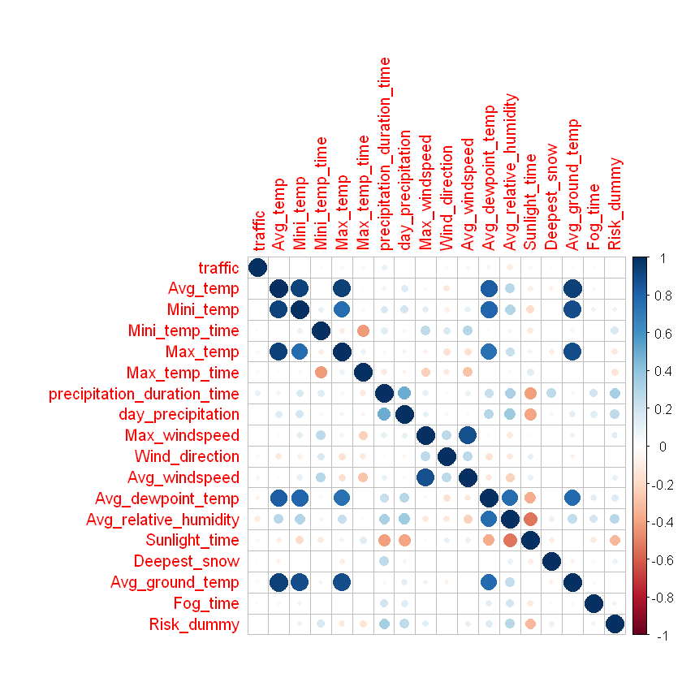

```r
library(corrplot)

correlations <- cor(df_numeric)
corrplot(correlations, method="circle")
```

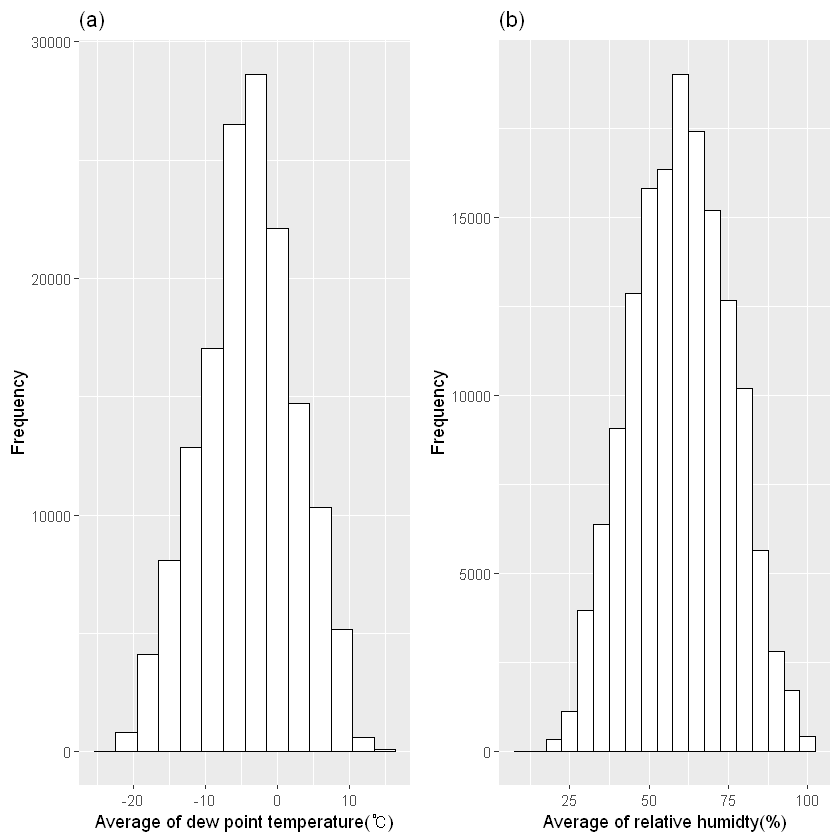

```r
dewpoint_hist <- ggplot(data = df, aes(x = Avg_dewpoint_temp)) +
  geom_histogram(binwidth = 3, fill = "white",color = "black") +
  xlab("Average of dew point temperature(℃)") + ylab("Frequency") + labs(title="(a)")

humidity_hist <- ggplot(data = df, aes(x = Avg_relative_humidity)) +
  geom_histogram(binwidth = 5, fill = "white",color = "black") +
  xlab("Average of relative humidty(%)") + ylab("Frequency") + labs(title="(b)")

grid.arrange(dewpoint_hist, humidity_hist, ncol = 2)
```

- 수치형변수에서 관심 공변량인 평균 이슬점과 평균 습도의 히스토그램을 그려보았다.
- 히스토그램에 의하면 두 공변량은 정규분포와 흡사한 모양을 갖고 있다. (해당 공변량의 데이터가 분포되어 골고루 있다.)
- 이 데이터에서 평균 이슬점은 주로 약 -7℃ 에서 0℃ 사이에 많은 빈도를 보인다.
- 평균 습도 또한 55% 에서 70% 사이에 많은 빈도를 보인다.

## 범주형변수 탐색

```r
pave_table <- df %>%
                group_by(pave) %>%
                summarize(freq=n()) %>%
                mutate(prop=freq/sum(freq))

surface_table <- df %>%
                  group_by(surface) %>%
                  summarize(freq=n()) %>%
                  mutate(prop=freq/sum(freq))

class_table <- df %>%
                group_by(classification) %>%
                summarize(freq=n()) %>%
                mutate(prop=freq/sum(freq))

# 각 결과는 kable() 함수를 이용해서 jpyter notebook 마크다운으로 넣었음
```

| pave | freq | prop |
| --- | --- | --- |
| 아스팔트 | 67044 | 0.444 |
| 콘크리트 | 83956 | 0.556 |

- 도로포장은 아스팔트와 콘크리트로 균일하게 이루어짐

| surface | CRCP | JCP | JRCP | LMC | PBSC | PSMA | SBS | SMA | 일반아스팔트 | 콘크리트마모층 |
| --- | --- | --- | --- | --- | --- | --- | --- | --- | --- | --- |
| freq | 2718 | 79577 | 604 | 302 | 4530 | 2869 | 302 | 20536 | 38807 | 755 |
| prop | 0.018 | 0.527 | 0.004 | 0.002 | 0.030 | 0.019 | 0.002 | 0.136 | 0.257 | 0.005 |

| classification | freq | prop |
| --- | --- | --- |
| 교량부 | 2114 | 0.014 |
| 터널부 | 1812 | 0.012 |
| 토공부 | 147074 | 0.974 |

- 토공부가 압도적으로 빈도수가 높다.

|  | CRCP | JCP | JRCP | LMC | PBSC | PSMA | SBS | SMA | 일반아스팔트 | 콘크리트마모층 |
| --- | --- | --- | --- | --- | --- | --- | --- | --- | --- | --- |
| 아스팔트 | 0 | 302 | 0 | 0 | 4228 | 2869 | 302 | 20536 | 38807 | 0 |
| 콘크리트 | 2718 | 79275 | 604 | 302 | 302 | 0 | 0 | 0 | 0 | 755 |

- 표층재는 주로 JCP와 일반아스팔트가 대부분이다.
- 아스팔트의 표층재는 JCP, PBSC, PSMA, SBS, SMA, 일반아스팔트로 구성
- 콘크리트의 표층재는 CRCP, JCP, JRCP, LMC, PBSC, 마모층으로 구성

#### 모든 변수의 Scatter matrix plot은 python으로 구현하였습니다. (python jupyter notebook 참고)